# Laptop

## *L3, Economie Appliquée et Analyse de données*

## *Université de Grenoble Alpes*

## 21/12/2024

### À propos du jeu de données

Ce jeu de données est une collection de caractéristiques liées à divers ordinateurs portables, telles que la marque, le type de processeur, la mémoire RAM, la capacité de stockage et d'autres spécifications. Le jeu de données inclut également les prix correspondants de ces ordinateurs portables. Ce jeu de données peut être utilisé pour une analyse de régression afin de prédire les prix des ordinateurs portables en fonction de leurs caractéristiques. https://www.kaggle.com/datasets/anubhavgoyal10/laptop-prices-dataset

## Objectif

L’objectif principal de cette étude est de comprendre les facteurs qui influencent le prix des ordinateurs portables à partir de caractéristiques techniques et commerciales extraites d’une base de données réelle. Plus précisément, le travail vise à : - Identifier les variables explicatives les plus déterminantes du prix (RAM, type de processeur, carte graphique, écran tactile, etc.), - Évaluer l'effet spécifique de chaque variable sur le prix des laptops, via des modèles de régression linéaire, - Comparer les tendances selon les marques afin de mettre en évidence d’éventuelles différences structurelles dans la politique tarifaire, - Vérifier les hypothèses classiques du modèle linéaire (normalité des résidus, homoscédasticité), - Enfin, proposer une modélisation plus robuste en ajoutant des termes d’interaction ou des transformations pertinentes, pour mieux expliquer la variabilité du prix. Ce type d’analyse peut servir à : - Aider un consommateur à mieux comprendre le lien entre les caractéristiques et le prix, - Soutenir un revendeur ou une plateforme e-commerce dans l’optimisation de ses stratégies tarifaires, - Fournir une base technique pour un modèle prédictif à intégrer dans une application de recommandation.

#### Nettoyage de données

```python
# Importation des librairies nécessaires
import numpy as np
import pandas as pd
```

```python
#Importation de ma base de données
data=pd.read_csv('C:/Projet data science/laptopPrice.csv')
```

```python
print(data.columns)
print(data.isna().sum())
```

```
Index(['brand', 'processor_brand', 'processor_name', 'processor_gnrtn',
       'ram_gb', 'ram_type', 'ssd', 'hdd', 'os', 'os_bit', 'graphic_card_gb',
       'weight', 'warranty', 'Touchscreen', 'msoffice', 'Price', 'rating',
       'Number of Ratings', 'Number of Reviews'],
      dtype='object')
brand                0
processor_brand      0
processor_name       0
processor_gnrtn      0
ram_gb               0
ram_type             0
ssd                  0
hdd                  0
os                   0
os_bit               0
graphic_card_gb      0
weight               0
warranty             0
Touchscreen          0
msoffice             0
Price                0
rating               0
Number of Ratings    0
Number of Reviews    0
dtype: int64
```

```python
data1=data[['brand', 'processor_brand', 'processor_name', 'processor_gnrtn',
       'ram_gb',  'ssd', 'hdd', 'os', 'os_bit', 'graphic_card_gb',
       'weight',  'Touchscreen',  'Price', 'rating']]
print(data1.head())
data1["Price"]=data1["Price"]*0.01
```

```
    brand processor_brand processor_name processor_gnrtn ram_gb     ssd  \
0    ASUS           Intel        Core i3            10th   4 GB    0 GB
1  Lenovo           Intel        Core i3            10th   4 GB    0 GB
2  Lenovo           Intel        Core i3            10th   4 GB    0 GB
3    ASUS           Intel        Core i5            10th   8 GB  512 GB
4    ASUS           Intel   Celeron Dual   Not Available   4 GB    0 GB

       hdd       os  os_bit graphic_card_gb  weight Touchscreen  Price  \
0  1024 GB  Windows  64-bit            0 GB  Casual          No  34649
1  1024 GB  Windows  64-bit            0 GB  Casual          No  38999
2  1024 GB  Windows  64-bit            0 GB  Casual          No  39999
3     0 GB  Windows  32-bit            2 GB  Casual          No  69990
4   512 GB  Windows  64-bit            0 GB  Casual          No  26990

    rating
0  2 stars
1  3 stars
2  3 stars
3  3 stars
4  3 stars
```

```python
#création d'une colonne de la capacité de stockage, rating, brand
# storage
def convertir_en_go(val):
    val = val.strip().upper()  # On met tout en majuscules pour standardiser
    if "TB" in val:
        return int(float(val.replace("TB", "").strip()) * 1000)
    elif "GB" in val:
        return int(float(val.replace("GB", "").strip()))
    elif "MB" in val:
        return int(float(val.replace("MB", "").strip()) / 1000)
    else:
        return 0

data1["storage"]=data1["hdd"].apply(convertir_en_go)+data1["ssd"].apply(convertir_en_go)
# rantings
data1["ratings"]=data1["rating"].str[0].astype(int)
# brand_image
def brand(val):
    val = val.strip().upper()
    if "APPLE" in val:
        return 1
    else:
        return 0
data1["brand_image"]=data1["brand"].apply(brand)
#RAM
def ram(val):
    val = val.strip().upper()  # On met tout en majuscules pour standardiser
    if "GB" in val:
        return int(float(val.replace("GB", "").strip()))
    else:
        return 0

data1["RAM"]=data1["ram_gb"].apply(ram)

#generation du processeur
def gnrt1(val):
    val = val.strip().upper()  # On met tout en majuscules pour standardiser
    if "TH" in val:
        return int(float(val.replace("TH", "").strip()))
    else:
        return 0

data1["processor_gnrt"]=data1["processor_gnrtn"].apply(gnrt1)
def gnrt2(val):
    if val < 10  :
        return 0
    else:
        return 1
data1["processor_gnrt"]=data1["processor_gnrt"].apply(gnrt2)

# Touchscreen
def ts(val):
    val = val.strip().upper()  # On met tout en majuscules pour standardiser
    if "NO" in val:
        return 0
    else:
        return 1

data1["T_screen"]=data1["Touchscreen"].apply(ts)

#os_bit et graphic card
def osbit(val):
    val = val.strip().upper()  # On met tout en majuscules pour standardiser
    if "-BIT" in val:
        return int(float(val.replace("-BIT", "").strip()))
    else:
        return 0

data1["OS_bit"]=data1["os_bit"].apply(osbit)
def GC(val):
    val = val.strip().upper()  # On met tout en majuscules pour standardiser
    if "GB" in val:
        return int(float(val.replace("GB", "").strip()))
    else:
        return 0
data1["Graphic_card"]=data1["graphic_card_gb"].apply(GC)
# poids

def poids(val):
    val = val.strip().upper()  # On met tout en majuscules pour standardiser
    if "CASUAL" in val:
        return 0
    elif "GAMING" in val:
        return 1
    else:
        return 1

data1["Weight"]=data1["weight"].apply(poids)
print(data1.head())
```

```
    brand processor_brand processor_name processor_gnrtn ram_gb     ssd  \
0    ASUS           Intel        Core i3            10th   4 GB    0 GB
1  Lenovo           Intel        Core i3            10th   4 GB    0 GB
2  Lenovo           Intel        Core i3            10th   4 GB    0 GB
3    ASUS           Intel        Core i5            10th   8 GB  512 GB
4    ASUS           Intel   Celeron Dual   Not Available   4 GB    0 GB

       hdd       os  os_bit graphic_card_gb  ...   rating storage  ratings  \
0  1024 GB  Windows  64-bit            0 GB  ...  2 stars    1024        2
1  1024 GB  Windows  64-bit            0 GB  ...  3 stars    1024        3
2  1024 GB  Windows  64-bit            0 GB  ...  3 stars    1024        3
3     0 GB  Windows  32-bit            2 GB  ...  3 stars     512        3
4   512 GB  Windows  64-bit            0 GB  ...  3 stars     512        3

  brand_image  RAM  processor_gnrt  T_screen  OS_bit  Graphic_card  Weight
0           0    4               1         0      64             0       0
1           0    4               1         0      64             0       0
2           0    4               1         0      64             0       0
3           0    8               1         0      32             2       0
4           0    4               0         0      64             0       0

[5 rows x 23 columns]
```

```python
print(data1.describe())
print(data1.columns)
```

```
             Price      storage     ratings  brand_image         RAM  \
count   823.000000   823.000000  823.000000   823.000000  823.000000
mean    767.451774   679.193196    3.562576     0.034022    8.680437
std     451.017905   341.610741    0.567282     0.181396    4.372408
min     169.900000   128.000000    1.000000     0.000000    4.000000
25%     460.950000   512.000000    3.000000     0.000000    4.000000
50%     649.900000   512.000000    4.000000     0.000000    8.000000
75%     896.360000  1024.000000    4.000000     0.000000    8.000000
max    4419.900000  3072.000000    5.000000     1.000000   32.000000

       processor_gnrt    T_screen      OS_bit  Graphic_card      Weight
count      823.000000  823.000000  823.000000    823.000000  823.000000
mean         0.657351    0.117861   59.761847      1.190765    0.368165
std          0.474884    0.322640   10.853667      2.026902    0.482600
min          0.000000    0.000000   32.000000      0.000000    0.000000
25%          0.000000    0.000000   64.000000      0.000000    0.000000
50%          1.000000    0.000000   64.000000      0.000000    0.000000
75%          1.000000    0.000000   64.000000      2.000000    1.000000
max          1.000000    1.000000   64.000000      8.000000    1.000000
Index(['brand', 'processor_brand', 'processor_name', 'processor_gnrtn',
       'ram_gb', 'ssd', 'hdd', 'os', 'os_bit', 'graphic_card_gb', 'weight',
       'Touchscreen', 'Price', 'rating', 'storage', 'ratings', 'brand_image',
       'RAM', 'processor_gnrt', 'T_screen', 'OS_bit', 'Graphic_card',
       'Weight'],
      dtype='object')
```

```python
donnees_laptop=data1[['brand', 'processor_brand', 'processor_name', 'processor_gnrtn',
       'ram_gb', 'ssd', 'hdd', 'os', 'os_bit', 'graphic_card_gb', 'weight',
       'Touchscreen', 'Price', 'rating', 'storage', 'ratings', 'brand_image',
       'RAM', 'processor_gnrt', 'T_screen', 'OS_bit', 'Graphic_card',
       'Weight']]
donnees_u=data1[['brand', 'Price', 'storage', 'ratings', 'brand_image',
       'RAM', 'processor_gnrt', 'T_screen', 'OS_bit', 'Graphic_card',
       'Weight']]
print(donnees_u.describe())
```

```
             Price      storage     ratings  brand_image         RAM  \
count   823.000000   823.000000  823.000000   823.000000  823.000000
mean    767.451774   679.193196    3.562576     0.034022    8.680437
std     451.017905   341.610741    0.567282     0.181396    4.372408
min     169.900000   128.000000    1.000000     0.000000    4.000000
25%     460.950000   512.000000    3.000000     0.000000    4.000000
50%     649.900000   512.000000    4.000000     0.000000    8.000000
75%     896.360000  1024.000000    4.000000     0.000000    8.000000
max    4419.900000  3072.000000    5.000000     1.000000   32.000000

       processor_gnrt    T_screen      OS_bit  Graphic_card      Weight
count      823.000000  823.000000  823.000000    823.000000  823.000000
mean         0.657351    0.117861   59.761847      1.190765    0.368165
std          0.474884    0.322640   10.853667      2.026902    0.482600
min          0.000000    0.000000   32.000000      0.000000    0.000000
25%          0.000000    0.000000   64.000000      0.000000    0.000000
50%          1.000000    0.000000   64.000000      0.000000    0.000000
75%          1.000000    0.000000   64.000000      2.000000    1.000000
max          1.000000    1.000000   64.000000      8.000000    1.000000
```

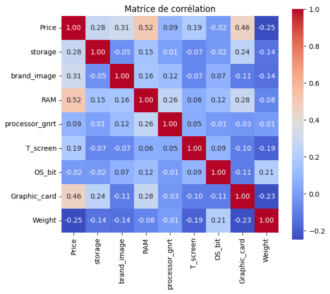

```python
import seaborn as sns
import matplotlib.pyplot as plt


#on garde uniquement les colonnes numériques
donnees_numeriques = donnees_u.select_dtypes(include=['int64', 'float64'])

#  calcul de la matrice de corrélation
corr = donnees_numeriques.corr()

#  visualisation avec heatmap
plt.figure(figsize=(7, 6))
sns.heatmap(corr, annot=True, cmap='coolwarm', fmt=".2f", square=True)
plt.title("Matrice de corrélation")
plt.show()
```

Apple

```
             Price      storage    ratings  brand_image        RAM  \
count    28.000000    28.000000  28.000000         28.0  28.000000
mean   1517.078571   594.285714   4.035714          1.0  12.428571
std     549.072555   296.042897   0.188982          0.0   5.692286
min     859.900000   256.000000   4.000000          1.0   4.000000
25%    1049.900000   448.000000   4.000000          1.0   8.000000
50%    1324.900000   512.000000   4.000000          1.0  12.000000
75%    1799.900000  1024.000000   4.000000          1.0  16.000000
max    3099.900000  1024.000000   5.000000          1.0  32.000000

       processor_gnrt  T_screen  OS_bit  Graphic_card  Weight
count       28.000000      28.0    28.0          28.0    28.0
mean         0.964286       0.0    64.0           0.0     0.0
std          0.188982       0.0     0.0           0.0     0.0
min          0.000000       0.0    64.0           0.0     0.0
25%          1.000000       0.0    64.0           0.0     0.0
50%          1.000000       0.0    64.0           0.0     0.0
75%          1.000000       0.0    64.0           0.0     0.0
max          1.000000       0.0    64.0           0.0     0.0
```

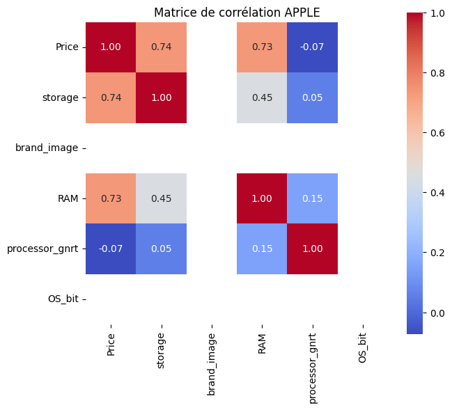

```python
donnees_apple=donnees_laptop[donnees_laptop["brand"]=="APPLE"]
print(donnees_apple.describe())
#on garde uniquement les colonnes numériques
donnees_numeriques_apple = donnees_apple.select_dtypes(include=['int64', 'float64'])
donnees_numeriques_apple = donnees_numeriques_apple.loc[:, (donnees_numeriques_apple != 0).any()]


#  calcul de la matrice de corrélation
corr_apple = donnees_numeriques_apple.corr()

#  visualisation avec heatmap
plt.figure(figsize=(7, 6))
sns.heatmap(corr_apple, annot=True, cmap='coolwarm', fmt=".2f", square=True)
plt.title("Matrice de corrélation APPLE")
plt.show()
```

DELL

```
             Price      storage     ratings  brand_image         RAM  \
count   151.000000   151.000000  151.000000        151.0  151.000000
mean    609.346623   703.576159    3.483444          0.0    7.814570
std     216.434740   383.394843    0.620261          0.0    3.309389
min     359.900000   256.000000    1.000000          0.0    4.000000
25%     429.900000   512.000000    3.000000          0.0    4.000000
50%     579.000000   512.000000    4.000000          0.0    8.000000
75%     724.495000  1024.000000    4.000000          0.0    8.000000
max    1399.900000  2048.000000    5.000000          0.0   16.000000

       processor_gnrt    T_screen      OS_bit  Graphic_card      Weight
count      151.000000  151.000000  151.000000    151.000000  151.000000
mean         0.761589    0.125828   61.245033      0.688742    0.496689
std          0.427529    0.332759    9.005899      1.327581    0.501653
min          0.000000    0.000000   32.000000      0.000000    0.000000
25%          1.000000    0.000000   64.000000      0.000000    0.000000
50%          1.000000    0.000000   64.000000      0.000000    0.000000
75%          1.000000    0.000000   64.000000      1.000000    1.000000
max          1.000000    1.000000   64.000000      6.000000    1.000000
```

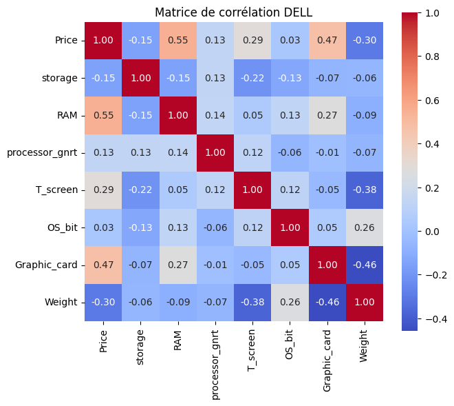

```python
donnees_dell=donnees_laptop[donnees_laptop["brand"]=="DELL"]
print(donnees_dell.describe())
#on garde uniquement les colonnes numériques
donnees_numeriques_dell = donnees_dell.select_dtypes(include=['int64', 'float64'])
donnees_numeriques_dell = donnees_numeriques_dell.loc[:, (donnees_numeriques_dell != 0).any()]


#  calcul de la matrice de corrélation
corr_dell = donnees_numeriques_dell.corr()

#  visualisation avec heatmap

plt.figure(figsize=(7, 6))
sns.heatmap(corr_dell, annot=True, cmap='coolwarm', fmt=".2f", square=True)
plt.title("Matrice de corrélation DELL")
plt.show()
```

HP

```
             Price      storage     ratings  brand_image         RAM  \
count   136.000000   136.000000  136.000000        136.0  136.000000
mean    736.402721   632.470588    3.683824          0.0    8.941176
std     366.252975   274.646411    0.526374          0.0    4.494877
min     264.700000   128.000000    2.000000          0.0    4.000000
25%     476.900000   512.000000    3.000000          0.0    4.000000
50%     599.990000   512.000000    4.000000          0.0    8.000000
75%     922.475000  1024.000000    4.000000          0.0   16.000000
max    2397.590000  1280.000000    5.000000          0.0   16.000000

       processor_gnrt    T_screen      OS_bit  Graphic_card      Weight
count      136.000000  136.000000  136.000000    136.000000  136.000000
mean         0.573529    0.191176   60.705882      1.058824    0.492647
std          0.496392    0.394681    9.760174      1.946563    0.501794
min          0.000000    0.000000   32.000000      0.000000    0.000000
25%          0.000000    0.000000   64.000000      0.000000    0.000000
50%          1.000000    0.000000   64.000000      0.000000    0.000000
75%          1.000000    0.000000   64.000000      2.000000    1.000000
max          1.000000    1.000000   64.000000      8.000000    1.000000
```

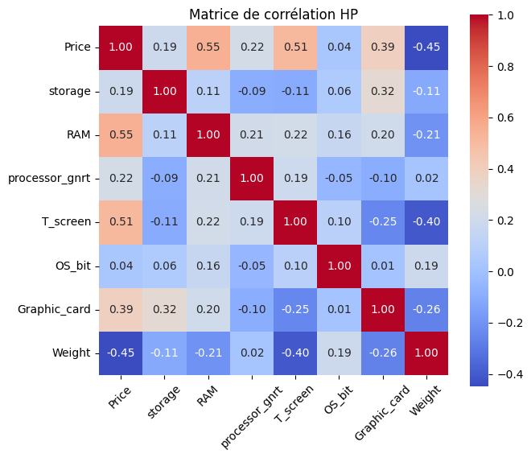

```python
donnees_hp=donnees_laptop[donnees_laptop["brand"]=="HP"]

print(donnees_hp.describe())
#on garde uniquement les colonnes numériques
donnees_numeriques_hp = donnees_hp.select_dtypes(include=['int64', 'float64'])
donnees_numeriques_hp = donnees_numeriques_hp.loc[:, (donnees_numeriques_hp != 0).any()]


#  calcul de la matrice de corrélation
corr_hp = donnees_numeriques_hp.corr()

#  visualisation avec heatmap
plt.figure(figsize=(7, 6))
sns.heatmap(corr_hp, annot=True, cmap='coolwarm', fmt=".2f", square=True)
plt.title("Matrice de corrélation HP")
plt.xticks(rotation=45)
plt.show()
```

```python
print(donnees_laptop.head())
```

```
    brand processor_brand processor_name processor_gnrtn ram_gb     ssd  \
0    ASUS           Intel        Core i3            10th   4 GB    0 GB
1  Lenovo           Intel        Core i3            10th   4 GB    0 GB
2  Lenovo           Intel        Core i3            10th   4 GB    0 GB
3    ASUS           Intel        Core i5            10th   8 GB  512 GB
4    ASUS           Intel   Celeron Dual   Not Available   4 GB    0 GB

       hdd       os  os_bit graphic_card_gb  ...   rating storage  ratings  \
0  1024 GB  Windows  64-bit            0 GB  ...  2 stars    1024        2
1  1024 GB  Windows  64-bit            0 GB  ...  3 stars    1024        3
2  1024 GB  Windows  64-bit            0 GB  ...  3 stars    1024        3
3     0 GB  Windows  32-bit            2 GB  ...  3 stars     512        3
4   512 GB  Windows  64-bit            0 GB  ...  3 stars     512        3

  brand_image  RAM  processor_gnrt  T_screen  OS_bit  Graphic_card  Weight
0           0    4               1         0      64             0       0
1           0    4               1         0      64             0       0
2           0    4               1         0      64             0       0
3           0    8               1         0      32             2       0
4           0    4               0         0      64             0       0

[5 rows x 23 columns]
```

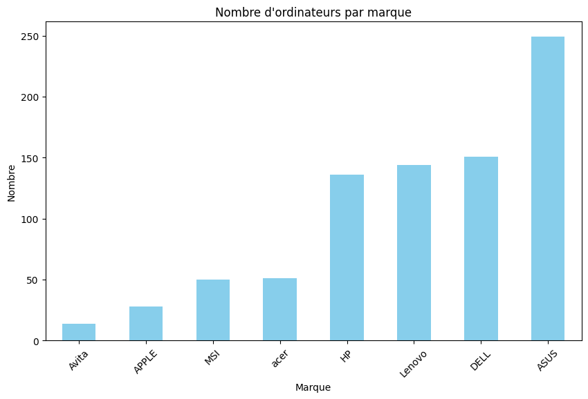

```python
# 1. Histogramme du nombre d'ordinateurs par marque
brand_counts = donnees_laptop['brand'].value_counts().sort_values()
plt.figure(figsize=(10, 6))
brand_counts.plot(kind='bar', color='skyblue')
plt.title("Nombre d'ordinateurs par marque")
plt.xlabel("Marque")
plt.ylabel("Nombre")
plt.xticks(rotation=45)
plt.show()
```

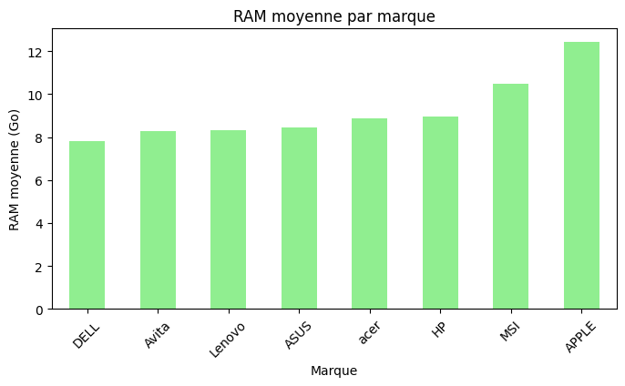

```python
# 2. RAM moyenne par marque
ram_moyenne = donnees_laptop.groupby('brand')['RAM'].mean().sort_values()
plt.figure(figsize=(8, 4))
ram_moyenne.plot(kind='bar', color='lightgreen')
plt.title("RAM moyenne par marque")
plt.xlabel("Marque")
plt.ylabel("RAM moyenne (Go)")
plt.xticks(rotation=45)
plt.show()
```

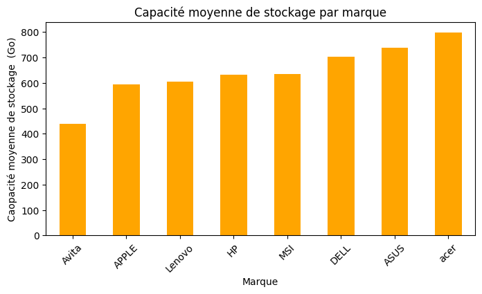

```python
# 3. Capacité de totale par marque
ssd_totale = donnees_laptop.groupby('brand')['storage'].mean().sort_values()
plt.figure(figsize=(8, 4))
ssd_totale.plot(kind='bar', color='orange')
plt.title("Capacité moyenne de stockage par marque")
plt.xlabel("Marque")
plt.ylabel("Caopacité moyenne de stockage  (Go)")
plt.xticks(rotation=45)
plt.show()
```

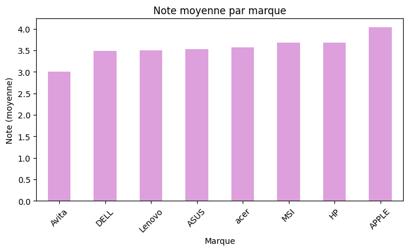

```python
# 4.  Note moyenne par marque
ratings_moyennes = donnees_laptop.groupby('brand')['ratings'].mean().sort_values()
plt.figure(figsize=(8, 4))
ratings_moyennes.plot(kind='bar', color='plum')
plt.title("Note moyenne par marque")
plt.xlabel("Marque")
plt.ylabel("Note (moyenne)")
plt.xticks(rotation=45)

plt.show()
```

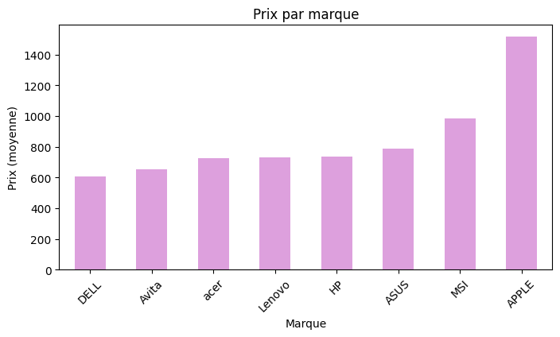

```python
# 4.  Note moyenne par marque
ratings_moyennes = donnees_laptop.groupby('brand')['Price'].mean().sort_values()
plt.figure(figsize=(8, 4))
ratings_moyennes.plot(kind='bar', color='plum')
plt.title("Prix par marque")
plt.xlabel("Marque")

plt.ylabel("Prix (moyenne)")
plt.xticks(rotation=45)

plt.show()
```

Regression

```python
donnees_laptop.columns
```

```
Index(['brand', 'processor_brand', 'processor_name', 'processor_gnrtn',
       'ram_gb', 'ssd', 'hdd', 'os', 'os_bit', 'graphic_card_gb', 'weight',
       'Touchscreen', 'Price', 'rating', 'storage', 'ratings', 'brand_image',
       'RAM', 'processor_gnrt', 'T_screen', 'OS_bit', 'Graphic_card',
       'Weight'],
      dtype='object')
```

## **Modélisation**

Une première régression linéaire est réalisée avec la bibliothèque statsmodels. Elle utilise comme variables explicatives : - La mémoire RAM, - Les notes (ratings), - Le stockage (storage), Et des variables transformées comme brand_image, processor_gnrt (génération de processeur), T_screen (écran tactile), OS_bit (système 32 ou 64 bits), Graphic_card, et le poids.

```python
import statsmodels.api as sm
donnees_laptop["ln_price"] = np.log(donnees_laptop["Price"])
def regression(donnees_laptop,label="modèle"):
    X=donnees_laptop[['RAM','ratings', 'storage', 'ratings', 'brand_image',
                      'processor_gnrt', 'T_screen', 'OS_bit', 'Graphic_card',
       'Weight']]
    y=donnees_laptop["ln_price"]
    X=sm.add_constant(X)
    modèle=sm.OLS(y,X).fit()
    print(label)
    print(modèle.summary())
    return modèle

regression(donnees_laptop)
```

```
modèle
                            OLS Regression Results
==============================================================================
Dep. Variable:               ln_price   R-squared:                       0.592
Model:                            OLS   Adj. R-squared:                  0.587
Method:                 Least Squares   F-statistic:                     130.9
Date:                Sat, 21 Jun 2025   Prob (F-statistic):          1.38e-151
Time:                        09:51:55   Log-Likelihood:                -215.40
No. Observations:                 823   AIC:                             450.8
Df Residuals:                     813   BIC:                             497.9
Df Model:                           9
Covariance Type:            nonrobust
==================================================================================
                     coef    std err          t      P>|t|      [0.025      0.975]
----------------------------------------------------------------------------------
const              6.1711      0.095     64.903      0.000       5.984       6.358
RAM                0.0400      0.003     14.077      0.000       0.034       0.046
ratings           -0.0410      0.010     -4.124      0.000      -0.061      -0.022
storage            0.0002   3.38e-05      4.569      0.000    8.79e-05       0.000
ratings           -0.0410      0.010     -4.124      0.000      -0.061      -0.022
brand_image        0.8769      0.066     13.364      0.000       0.748       1.006
processor_gnrt    -0.0276      0.024     -1.133      0.258      -0.075       0.020
T_screen           0.4582      0.036     12.660      0.000       0.387       0.529
OS_bit            -0.0002      0.001     -0.154      0.877      -0.002       0.002
Graphic_card       0.1044      0.006     16.855      0.000       0.092       0.117
Weight             0.0071      0.025      0.279      0.780      -0.043       0.057
==============================================================================
Omnibus:                       60.505   Durbin-Watson:                   1.062
Prob(Omnibus):                  0.000   Jarque-Bera (JB):               95.104
Skew:                           0.546   Prob(JB):                     2.23e-21
Kurtosis:                       4.258   Cond. No.                     3.91e+18
==============================================================================

Notes:
[1] Standard Errors assume that the covariance matrix of the errors is correctly specified.
[2] The smallest eigenvalue is 3.13e-29. This might indicate that there are
strong multicollinearity problems or that the design matrix is singular.
```

```
<statsmodels.regression.linear_model.RegressionResultsWrapper at 0x1ccba643680>
```

```python
def regression_par_marque(donnees_laptop):
    marques = donnees_laptop["brand"].unique()

    resultats = {}  # Pour stocker les modèles estimés par marque

    for marque in marques:
        print(f"\n============ Régression pour la marque : {marque} ===========")

        sous_ensemble = donnees_laptop[donnees_laptop["brand"] == marque]

        # Vérification : au moins 10 lignes pour éviter des erreurs de régression
        if len(sous_ensemble) < 10:
            print(f" Trop peu d'observations pour {marque} (n = {len(sous_ensemble)}), régression ignorée.")
            continue

        try:
            X = sous_ensemble[['RAM', 'ratings', 'storage', 'brand_image',
                               'processor_gnrt', 'T_screen', 'OS_bit', 'Graphic_card', 'Weight']]
            y = sous_ensemble["ln_price"]

            X = sm.add_constant(X)
            modèle = sm.OLS(y, X).fit()

            print(modèle.summary())
            resultats[marque] = modèle

        except Exception as e:
            print(f" Erreur pour la marque {marque} : {e}")

    return resultats

# Appel de la fonction
résultats_par_marque = regression_par_marque(donnees_laptop)
```

```
============ Régression pour la marque : ASUS ===========
                            OLS Regression Results
==============================================================================
Dep. Variable:               ln_price   R-squared:                       0.567
Model:                            OLS   Adj. R-squared:                  0.552
Method:                 Least Squares   F-statistic:                     39.24
Date:                Sat, 21 Jun 2025   Prob (F-statistic):           1.44e-39
Time:                        09:51:55   Log-Likelihood:                -102.96
No. Observations:                 249   AIC:                             223.9
Df Residuals:                     240   BIC:                             255.6
Df Model:                           8
Covariance Type:            nonrobust
==================================================================================
                     coef    std err          t      P>|t|      [0.025      0.975]
----------------------------------------------------------------------------------
const              5.7378      0.196     29.277      0.000       5.352       6.124
RAM                0.0383      0.006      6.558      0.000       0.027       0.050
ratings           -0.0568      0.041     -1.370      0.172      -0.138       0.025
storage            0.0004   6.89e-05      5.445      0.000       0.000       0.001
brand_image     6.065e-15   2.12e-16     28.639      0.000    5.65e-15    6.48e-15
processor_gnrt    -0.0869      0.051     -1.697      0.091      -0.188       0.014
T_screen           0.4307      0.075      5.763      0.000       0.283       0.578
OS_bit             0.0042      0.002      2.030      0.043       0.000       0.008
Graphic_card       0.1098      0.012      9.025      0.000       0.086       0.134
Weight            -0.0772      0.056     -1.376      0.170      -0.188       0.033
==============================================================================
Omnibus:                        0.248   Durbin-Watson:                   0.986
Prob(Omnibus):                  0.883   Jarque-Bera (JB):                0.219
Skew:                           0.072   Prob(JB):                        0.896
Kurtosis:                       2.979   Cond. No.                     2.46e+19
==============================================================================

Notes:
[1] Standard Errors assume that the covariance matrix of the errors is correctly specified.
[2] The smallest eigenvalue is 2.8e-31. This might indicate that there are
strong multicollinearity problems or that the design matrix is singular.

============ Régression pour la marque : Lenovo ===========
                            OLS Regression Results
==============================================================================
```

[output cut: 238 more lines]

```
T_screen                0          0        nan        nan           0           0
OS_bit             0.1103      0.015      7.392      0.000       0.079       0.141
Graphic_card            0          0        nan        nan           0           0
Weight                  0          0        nan        nan           0           0
==============================================================================
Omnibus:                        2.858   Durbin-Watson:                   1.466
Prob(Omnibus):                  0.240   Jarque-Bera (JB):                2.355
Skew:                           0.698   Prob(JB):                        0.308
Kurtosis:                       2.737   Cond. No.                          inf
==============================================================================

Notes:
[1] Standard Errors assume that the covariance matrix of the errors is correctly specified.
[2] The smallest eigenvalue is      0. This might indicate that there are
strong multicollinearity problems or that the design matrix is singular.
```

## **→ Diagnostic de l'Hétéroscédasticité du 1er modèle**

```
modèle
                            OLS Regression Results
==============================================================================
Dep. Variable:               ln_price   R-squared:                       0.592
Model:                            OLS   Adj. R-squared:                  0.587
Method:                 Least Squares   F-statistic:                     130.9
Date:                Sat, 21 Jun 2025   Prob (F-statistic):          1.38e-151
Time:                        09:51:56   Log-Likelihood:                -215.40
No. Observations:                 823   AIC:                             450.8
Df Residuals:                     813   BIC:                             497.9
Df Model:                           9
Covariance Type:            nonrobust
==================================================================================
                     coef    std err          t      P>|t|      [0.025      0.975]
----------------------------------------------------------------------------------
const              6.1711      0.095     64.903      0.000       5.984       6.358
RAM                0.0400      0.003     14.077      0.000       0.034       0.046
ratings           -0.0410      0.010     -4.124      0.000      -0.061      -0.022
storage            0.0002   3.38e-05      4.569      0.000    8.79e-05       0.000
ratings           -0.0410      0.010     -4.124      0.000      -0.061      -0.022
brand_image        0.8769      0.066     13.364      0.000       0.748       1.006
processor_gnrt    -0.0276      0.024     -1.133      0.258      -0.075       0.020
T_screen           0.4582      0.036     12.660      0.000       0.387       0.529
OS_bit            -0.0002      0.001     -0.154      0.877      -0.002       0.002
Graphic_card       0.1044      0.006     16.855      0.000       0.092       0.117
Weight             0.0071      0.025      0.279      0.780      -0.043       0.057
==============================================================================
Omnibus:                       60.505   Durbin-Watson:                   1.062
Prob(Omnibus):                  0.000   Jarque-Bera (JB):               95.104
Skew:                           0.546   Prob(JB):                     2.23e-21
Kurtosis:                       4.258   Cond. No.                     3.91e+18
==============================================================================

Notes:
[1] Standard Errors assume that the covariance matrix of the errors is correctly specified.
[2] The smallest eigenvalue is 3.13e-29. This might indicate that there are
strong multicollinearity problems or that the design matrix is singular.
```

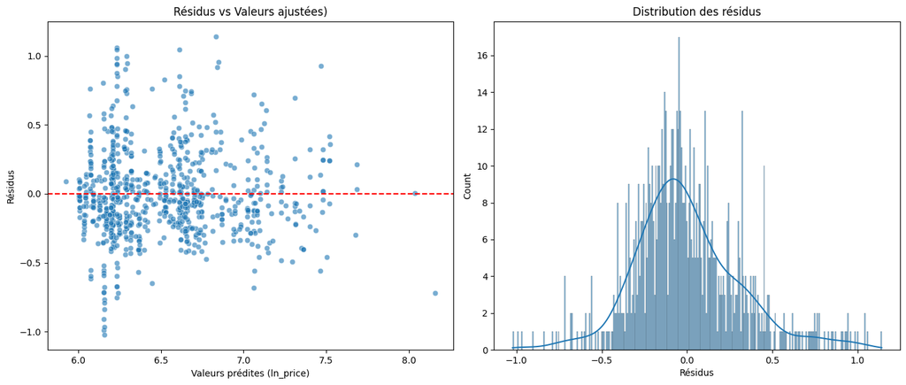

```python
def diagnostiquer_heteroscedasticite(modele1):
    # Résidus (perturbations)
    residus = modele1.resid
    valeurs_predites = modele1.fittedvalues

    plt.figure(figsize=(14, 6))

    #  1. Graphique des résidus vs valeurs ajustées
    plt.subplot(1, 2, 1)
    sns.scatterplot(x=valeurs_predites, y=residus, alpha=0.6)
    plt.axhline(0, color='red', linestyle='--')
    plt.xlabel("Valeurs prédites (ln_price)")
    plt.ylabel("Résidus")
    plt.title("Résidus vs Valeurs ajustées)")

    # 2. Histogramme + courbe KDE des résidus
    plt.subplot(1, 2, 2)
    sns.histplot(residus, kde=True, bins=300)
    plt.xlabel("Résidus")
    plt.title("Distribution des résidus")

    plt.tight_layout()
    plt.show()
modele1 = regression(donnees_laptop)
diagnostiquer_heteroscedasticite(modele1)
```

Hetero-BP

```python
from statsmodels.stats.diagnostic import het_breuschpagan

residuals = modele1.resid
exog = modele1.model.exog
test = het_breuschpagan(residuals, exog)

labels = ['Statistique LM', 'p-value', 'F-statistique', 'p-value F']
dict(zip(labels, test))
```

```
{'Statistique LM': 86.62521096564667,
 'p-value': 2.4936653428281735e-14,
 'F-statistique': 10.626577897230296,
 'p-value F': 1.1224608920901893e-15}
```

Le modèle présente de l’hétéroscédasticité → les erreurs ne sont pas de variance constante.

### Correction de l'hétéroscédasticité

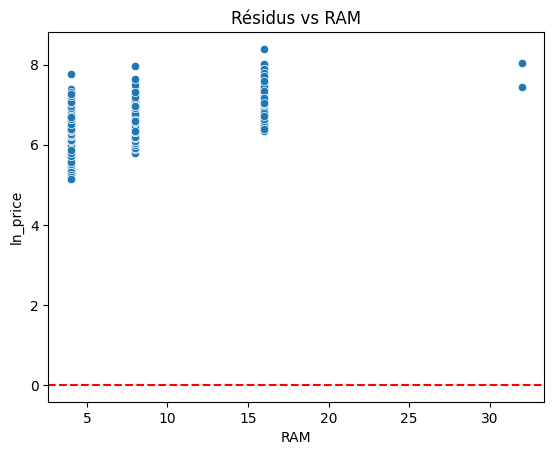

```python
sns.scatterplot(x=donnees_laptop["RAM"], y=donnees_laptop["ln_price"])
plt.axhline(0, color='red', linestyle='--')
plt.title("Résidus vs RAM")
plt.show()
```

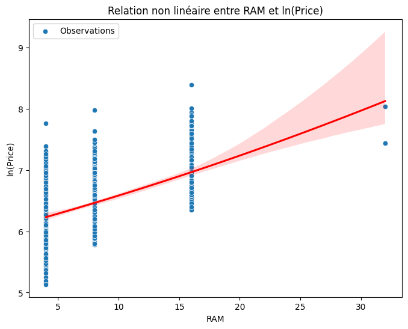

```python
plt.figure(figsize=(8, 6))
sns.scatterplot(x=donnees_laptop["RAM"], y=donnees_laptop["ln_price"], label="Observations")

sns.regplot(
    x=donnees_laptop["RAM"],
    y=donnees_laptop["ln_price"],
    order=2,
    scatter=False,
    color='red',

)

plt.title("Relation non linéaire entre RAM et ln(Price)")
plt.xlabel("RAM")
plt.ylabel("ln(Price)")
plt.legend()
plt.show()
```

```python
donnees_laptop["RAM2"] = donnees_laptop["RAM"]**2
```

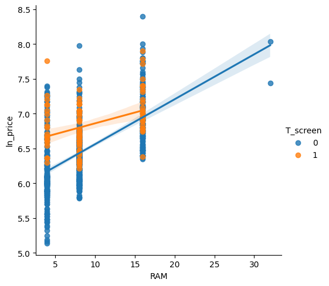

```python
sns.lmplot(data=donnees_laptop, x="RAM", y="ln_price", hue="T_screen")
```

```python
donnees_laptop["interaction_RAM_touch"] = donnees_laptop["RAM"] * donnees_laptop["T_screen"]
```

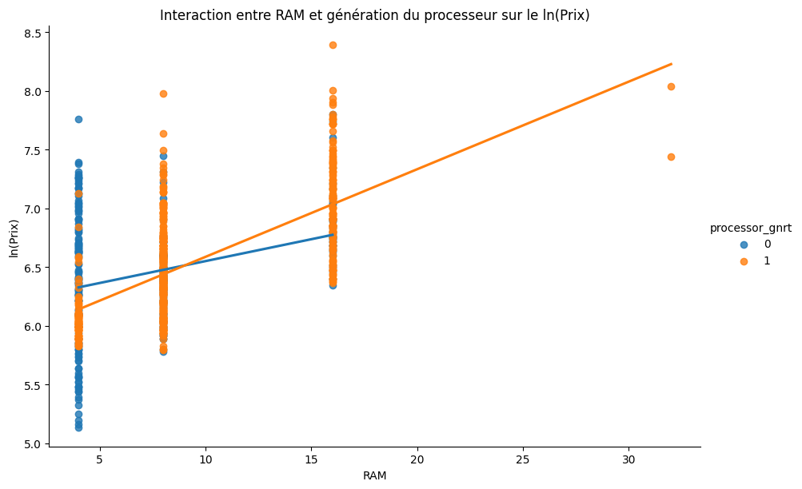

```python
donnees_laptop["processor_gnrt"] = donnees_laptop["processor_gnrt"].astype(int)

# Tracer la relation entre RAM et ln_price selon chaque génération de processeur
sns.lmplot(
    data=donnees_laptop,
    x="RAM",
    y="ln_price",
    hue="processor_gnrt",   # Une courbe par génération
    ci=None,
    height=6,
    aspect=1.5
)

plt.title("Interaction entre RAM et génération du processeur sur le ln(Prix)")
plt.xlabel("RAM")
plt.ylabel("ln(Prix)")
plt.show()
```

```python
donnees_laptop["interaction_RAM_proc"] = donnees_laptop["RAM"] * donnees_laptop["processor_gnrt"]
```

### 2ème modèle avec une variable quadratique et 2 variable d'interaction

```python
def regression2(donnees_laptop, label="modèle2"):
    cols = ['RAM', 'ratings', 'storage', 'brand_image',
            'processor_gnrt', 'T_screen', 'OS_bit', 'Graphic_card',
            'Weight','RAM2','interaction_RAM_proc','interaction_RAM_touch']

    donnees_laptop[cols] = donnees_laptop[cols].apply(pd.to_numeric, errors='coerce')
    donnees_laptop = donnees_laptop.dropna(subset=cols + ['ln_price'])

    Z = donnees_laptop[cols]
    y = donnees_laptop["ln_price"]
    Z = sm.add_constant(Z)
    modèle2 = sm.OLS(y, Z).fit()
    print(label)
    print(modèle2.summary())
    return modèle2
    plt.figure(figsize=(12,10))
    sns.heatmap(Z.corr(), annot=True, cmap='coolwarm')
    plt.title("Matrice de corrélation")
    plt.show()

regression2(donnees_laptop)
```

```
modèle2
                            OLS Regression Results
==============================================================================
Dep. Variable:               ln_price   R-squared:                       0.599
Model:                            OLS   Adj. R-squared:                  0.594
Method:                 Least Squares   F-statistic:                     101.0
Date:                Sat, 21 Jun 2025   Prob (F-statistic):          8.39e-152
Time:                        09:51:57   Log-Likelihood:                -207.48
No. Observations:                 823   AIC:                             441.0
Df Residuals:                     810   BIC:                             502.2
Df Model:                          12
Covariance Type:            nonrobust
=========================================================================================
                            coef    std err          t      P>|t|      [0.025      0.975]
-----------------------------------------------------------------------------------------
const                     6.1764      0.102     60.842      0.000       5.977       6.376
RAM                       0.0503      0.010      5.057      0.000       0.031       0.070
ratings                  -0.0837      0.020     -4.228      0.000      -0.123      -0.045
storage                   0.0002   3.36e-05      4.616      0.000    8.92e-05       0.000
brand_image               0.8593      0.066     13.083      0.000       0.730       0.988
processor_gnrt           -0.1924      0.054     -3.542      0.000      -0.299      -0.086
T_screen                  0.5808      0.080      7.260      0.000       0.424       0.738
OS_bit                   -0.0003      0.001     -0.298      0.765      -0.002       0.002
Graphic_card              0.1017      0.006     16.389      0.000       0.090       0.114
Weight                    0.0121      0.026      0.474      0.636      -0.038       0.062
RAM2                     -0.0010      0.000     -2.223      0.026      -0.002      -0.000
interaction_RAM_proc      0.0199      0.006      3.318      0.001       0.008       0.032
interaction_RAM_touch    -0.0144      0.008     -1.839      0.066      -0.030       0.001
==============================================================================
Omnibus:                       53.602   Durbin-Watson:                   1.085
Prob(Omnibus):                  0.000   Jarque-Bera (JB):               88.504
Skew:                           0.479   Prob(JB):                     6.05e-20
Kurtosis:                       4.290   Cond. No.                     7.26e+03
==============================================================================

Notes:
[1] Standard Errors assume that the covariance matrix of the errors is correctly specified.
[2] The condition number is large, 7.26e+03. This might indicate that there are
strong multicollinearity or other numerical problems.
```

```
<statsmodels.regression.linear_model.RegressionResultsWrapper at 0x1ccb7c48d10>
```

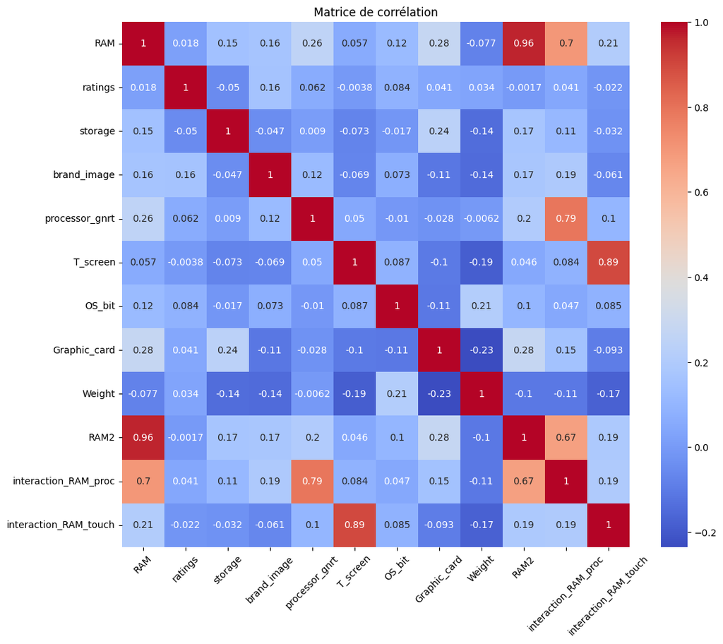

```python
import seaborn as sns
import matplotlib.pyplot as plt
cols = ['RAM', 'ratings', 'storage', 'brand_image',
            'processor_gnrt', 'T_screen', 'OS_bit', 'Graphic_card',
            'Weight','RAM2','interaction_RAM_proc','interaction_RAM_touch']


donnees_laptop[cols] = donnees_laptop[cols].apply(pd.to_numeric, errors='coerce')
donnees_laptop = donnees_laptop.dropna(subset=cols + ['ln_price'])

Z = donnees_laptop[cols]
y = donnees_laptop["ln_price"]
plt.figure(figsize=(12,10))
sns.heatmap(Z.corr(), annot=True, cmap='coolwarm')
plt.title("Matrice de corrélation")
plt.xticks(rotation=45)
plt.show()
```

## **→ Diagnostic de l'Hétéroscédasticité du 2ème modèle**

```
{'Statistique LM': 111.4035647633707, 'p-value': 3.156630171957004e-18, 'F-statistique': 10.567423119576144, 'p-value F': 1.21425494326558e-19}
```

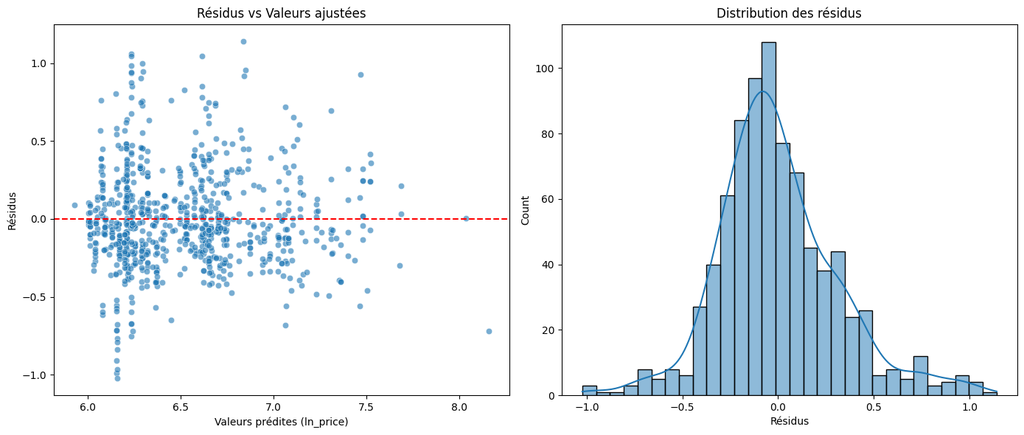

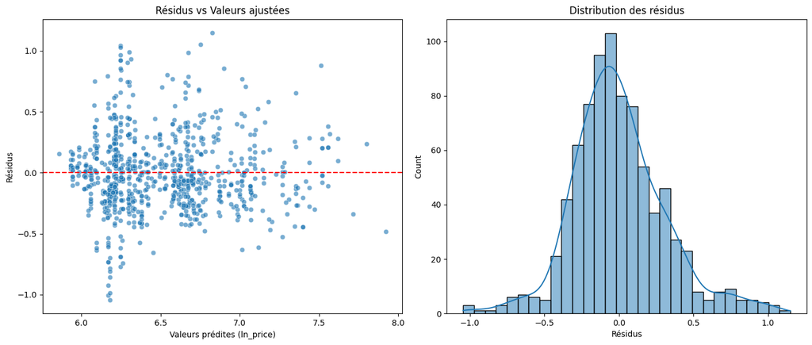

```python
import statsmodels.api as sm
from statsmodels.stats.diagnostic import het_breuschpagan
import seaborn as sns
import matplotlib.pyplot as plt

# Régression linéaire
Z = sm.add_constant(Z)  # Ajout de la constante
modèle2 = sm.OLS(y, Z).fit()

# Fonction de diagnostic de l'hétéroscédasticité
def diagnostiquer_heteroscedasticite(modèle):
    residus = modèle.resid
    valeurs_predites = modèle.fittedvalues

    plt.figure(figsize=(14, 6))

    # 1. Résidus vs valeurs ajustées
    plt.subplot(1, 2, 1)
    sns.scatterplot(x=valeurs_predites, y=residus, alpha=0.6)
    plt.axhline(0, color='red', linestyle='--')
    plt.xlabel("Valeurs prédites (ln_price)")
    plt.ylabel("Résidus")
    plt.title("Résidus vs Valeurs ajustées")

    # 2. Histogramme + KDE
    plt.subplot(1, 2, 2)
    sns.histplot(residus, kde=True, bins=30)
    plt.xlabel("Résidus")
    plt.title("Distribution des résidus")

    plt.tight_layout()
    plt.show()

# Breusch-Pagan test
residuals = modèle2.resid
exog = modèle2.model.exog
test = het_breuschpagan(residuals, exog)

# Affichage des résultats du test
labels = ['Statistique LM', 'p-value', 'F-statistique', 'p-value F']
resultats_bp = dict(zip(labels, test))
print(resultats_bp)

# Diagnostic graphique
diagnostiquer_heteroscedasticite(modele1)
diagnostiquer_heteroscedasticite(modèle2)
```

### 1. Estimation robuste de la variance

```python
modèle2_corrigé = sm.OLS(y, Z).fit(cov_type='HC0')
print(modèle2_corrigé.summary())
```

```
                            OLS Regression Results
==============================================================================
Dep. Variable:               ln_price   R-squared:                       0.599
Model:                            OLS   Adj. R-squared:                  0.594
Method:                 Least Squares   F-statistic:                     144.6
Date:                Sat, 21 Jun 2025   Prob (F-statistic):          6.05e-192
Time:                        09:51:58   Log-Likelihood:                -207.48
No. Observations:                 823   AIC:                             441.0
Df Residuals:                     810   BIC:                             502.2
Df Model:                          12
Covariance Type:                  HC0
=========================================================================================
                            coef    std err          z      P>|z|      [0.025      0.975]
-----------------------------------------------------------------------------------------
const                     6.1764      0.127     48.460      0.000       5.927       6.426
RAM                       0.0503      0.011      4.639      0.000       0.029       0.072
ratings                  -0.0837      0.022     -3.861      0.000      -0.126      -0.041
storage                   0.0002   3.84e-05      4.040      0.000    7.99e-05       0.000
brand_image               0.8593      0.050     17.143      0.000       0.761       0.958
processor_gnrt           -0.1924      0.055     -3.469      0.001      -0.301      -0.084
T_screen                  0.5808      0.067      8.642      0.000       0.449       0.713
OS_bit                   -0.0003      0.001     -0.241      0.809      -0.003       0.002
Graphic_card              0.1017      0.007     15.384      0.000       0.089       0.115
Weight                    0.0121      0.024      0.513      0.608      -0.034       0.058
RAM2                     -0.0010      0.000     -2.124      0.034      -0.002   -7.62e-05
interaction_RAM_proc      0.0199      0.006      3.310      0.001       0.008       0.032
interaction_RAM_touch    -0.0144      0.007     -2.141      0.032      -0.028      -0.001
==============================================================================
Omnibus:                       53.602   Durbin-Watson:                   1.085
Prob(Omnibus):                  0.000   Jarque-Bera (JB):               88.504
Skew:                           0.479   Prob(JB):                     6.05e-20
Kurtosis:                       4.290   Cond. No.                     7.26e+03
==============================================================================

Notes:
[1] Standard Errors are heteroscedasticity robust (HC0)
[2] The condition number is large, 7.26e+03. This might indicate that there are
strong multicollinearity or other numerical problems.
```

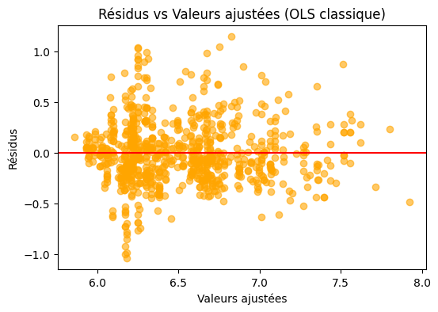

```python
plt.figure(figsize=(6,4))
plt.scatter(modèle2.fittedvalues, modèle2.resid, alpha=0.6, c='orange', label='Robuste')
plt.axhline(0, color='red', linestyle='-')
plt.xlabel("Valeurs ajustées")
plt.ylabel("Résidus")
plt.title("Résidus vs Valeurs ajustées (OLS classique)")
plt.show()
```

### 2. Régression pondérée WLS

```python
residus = modèle2.resid
poids = 1 / (residus**2)

modele_wls = sm.WLS(y, Z, weights=poids).fit()
print(modele_wls.summary())
```

```
                            WLS Regression Results
==============================================================================
Dep. Variable:               ln_price   R-squared:                       1.000
Model:                            WLS   Adj. R-squared:                  1.000
Method:                 Least Squares   F-statistic:                 5.743e+05
Date:                Sat, 21 Jun 2025   Prob (F-statistic):               0.00
Time:                        09:51:59   Log-Likelihood:                 421.81
No. Observations:                 823   AIC:                            -817.6
Df Residuals:                     810   BIC:                            -756.4
Df Model:                          12
Covariance Type:            nonrobust
=========================================================================================
                            coef    std err          t      P>|t|      [0.025      0.975]
-----------------------------------------------------------------------------------------
const                     6.1767      0.005   1150.471      0.000       6.166       6.187
RAM                       0.0504      0.001     88.864      0.000       0.049       0.052
ratings                  -0.0838      0.001    -74.602      0.000      -0.086      -0.082
storage                   0.0002   2.72e-06     57.007      0.000       0.000       0.000
brand_image               0.8630      0.004    240.810      0.000       0.856       0.870
processor_gnrt           -0.1928      0.002    -77.248      0.000      -0.198      -0.188
T_screen                  0.5550      0.012     46.509      0.000       0.532       0.578
OS_bit                   -0.0003   4.83e-05     -7.196      0.000      -0.000      -0.000
Graphic_card              0.1020      0.000    280.587      0.000       0.101       0.103
Weight                    0.0135      0.003      5.336      0.000       0.009       0.018
RAM2                     -0.0010   4.68e-05    -21.287      0.000      -0.001      -0.001
interaction_RAM_proc      0.0200      0.000     58.731      0.000       0.019       0.021
interaction_RAM_touch    -0.0126      0.001    -14.344      0.000      -0.014      -0.011
==============================================================================
Omnibus:                     3276.723   Durbin-Watson:                   1.273
Prob(Omnibus):                  0.000   Jarque-Bera (JB):              133.889
Skew:                           0.172   Prob(JB):                     8.44e-30
Kurtosis:                       1.054   Cond. No.                     9.87e+05
==============================================================================

Notes:
[1] Standard Errors assume that the covariance matrix of the errors is correctly specified.
[2] The condition number is large, 9.87e+05. This might indicate that there are
strong multicollinearity or other numerical problems.
```

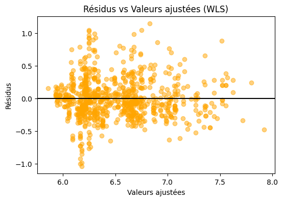

```python
plt.figure(figsize=(6,4))
#plt.scatter(modele_wls.fittedvalues, modele_wls.resid,  alpha=0.5, c='dodgerblue', label='OLS')
#plt.scatter(modèle2.fittedvalues, modèle2.resid, alpha=0.5, c='dodgerblue', label='OLS')
plt.scatter(modele_wls.fittedvalues, modele_wls.resid, alpha=0.5, c='orange', label='WLS')
plt.axhline(0, color='black', linestyle='-')
plt.xlabel("Valeurs ajustées")
plt.ylabel("Résidus")
plt.title("Résidus vs Valeurs ajustées (WLS)")
plt.show()
```

## 2. **Vérifier la multicolinéarité**

```python
from statsmodels.stats.outliers_influence import variance_inflation_factor

vif = pd.DataFrame()
vif["Variable"] = Z.columns
vif["VIF"] = [variance_inflation_factor(Z.values, i) for i in range(Z.shape[1])]
print(vif)
```

```
                 Variable        VIF
0                   const  86.109652
1                     RAM  15.767629
2                 ratings   1.053194
3                 storage   1.101138
4             brand_image   1.184641
5          processor_gnrt   5.554625
6                T_screen   5.560451
7                  OS_bit   1.113436
8            Graphic_card   1.321345
9                  Weight   1.267546
10                   RAM2  16.173096
11   interaction_RAM_proc   9.811842
12  interaction_RAM_touch   5.822722
```

## 3.**Test la normalité des résidus**

```
Stat JB : 88.50, p-value : 0.0000
```

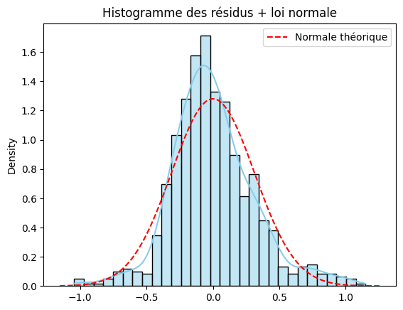

```python
from scipy.stats import jarque_bera
jb_stat, jb_pvalue = jarque_bera(modèle2_corrigé.resid)
print(f"Stat JB : {jb_stat:.2f}, p-value : {jb_pvalue:.4f}")
import scipy.stats as stats

resid = modèle2_corrigé.resid
sns.histplot(resid, kde=True, color='skyblue', stat="density")
mu, std = resid.mean(), resid.std()
xmin, xmax = plt.xlim()
x = np.linspace(xmin, xmax, 100)
plt.plot(x, stats.norm.pdf(x, mu, std), color='red', linestyle='--', label='Normale théorique')
plt.title("Histogramme des résidus + loi normale")
plt.legend()
plt.show()
```

## 4. **Évaluation de la qualité du modèle : Analyse des valeurs influentes**

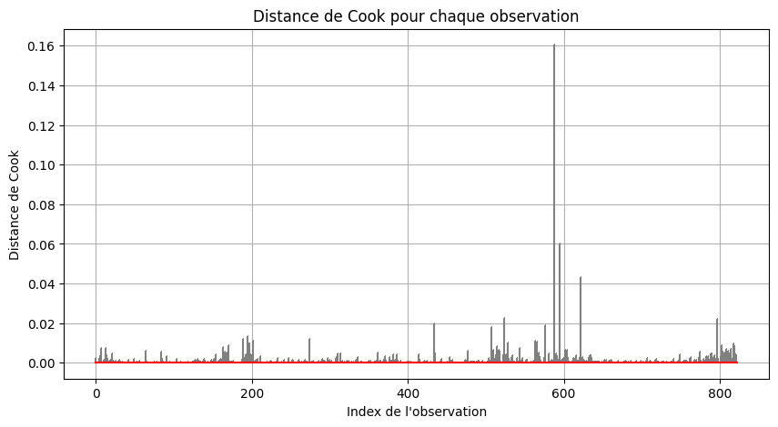

```python
import matplotlib.pyplot as plt

influence = modèle2_corrigé.get_influence()
cooks_d = influence.cooks_distance[0]

# Visualisation des points influents avec Distance de Cook
plt.figure(figsize=(10,5))
plt.stem(cooks_d, markerfmt=",", linefmt="grey", basefmt="red")
plt.title("Distance de Cook pour chaque observation")
plt.xlabel("Index de l'observation")
plt.ylabel("Distance de Cook")
plt.grid(True)
plt.show()
```

## 5. **Validation croisée**

```python
from sklearn.model_selection import cross_val_score
from sklearn.linear_model import LinearRegression
from sklearn.model_selection import KFold

X = Z.drop(columns='const')  # enlever constante pour sklearn
y = donnees_laptop["ln_price"]

model = LinearRegression()
cv = KFold(n_splits=5, shuffle=True, random_state=42)
scores = cross_val_score(model, X, y, cv=cv, scoring='r2')
print(f"R² validation croisée : {scores.mean():.3f}")
```

```
R² validation croisée : 0.583
```

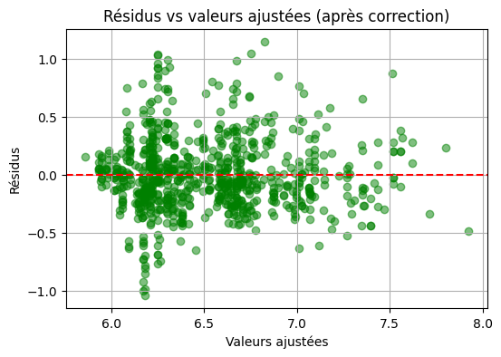

```python
plt.figure(figsize=(6,4))
plt.scatter(modèle2_corrigé.fittedvalues, modèle2_corrigé.resid, alpha=0.5, c='green')
plt.axhline(0, color='red', linestyle='--')
plt.xlabel("Valeurs ajustées")
plt.ylabel("Résidus")
plt.title("Résidus vs valeurs ajustées (après correction)")
plt.grid(True)
plt.show()
```

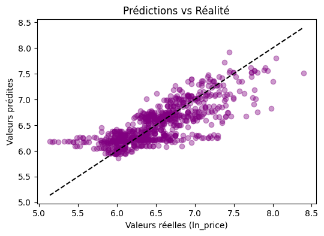

```python
plt.figure(figsize=(6,4))
plt.scatter(y, modèle2_corrigé.fittedvalues, alpha=0.4, c='purple')
plt.plot([y.min(), y.max()], [y.min(), y.max()], 'k--')
plt.xlabel("Valeurs réelles (ln_price)")
plt.ylabel("Valeurs prédites")
plt.title("Prédictions vs Réalité")
plt.show()
```

```python
print(modèle2_corrigé.summary())
```

```
                            OLS Regression Results
==============================================================================
Dep. Variable:               ln_price   R-squared:                       0.599
Model:                            OLS   Adj. R-squared:                  0.594
Method:                 Least Squares   F-statistic:                     144.6
Date:                Sat, 21 Jun 2025   Prob (F-statistic):          6.05e-192
Time:                        09:51:59   Log-Likelihood:                -207.48
No. Observations:                 823   AIC:                             441.0
Df Residuals:                     810   BIC:                             502.2
Df Model:                          12
Covariance Type:                  HC0
=========================================================================================
                            coef    std err          z      P>|z|      [0.025      0.975]
-----------------------------------------------------------------------------------------
const                     6.1764      0.127     48.460      0.000       5.927       6.426
RAM                       0.0503      0.011      4.639      0.000       0.029       0.072
ratings                  -0.0837      0.022     -3.861      0.000      -0.126      -0.041
storage                   0.0002   3.84e-05      4.040      0.000    7.99e-05       0.000
brand_image               0.8593      0.050     17.143      0.000       0.761       0.958
processor_gnrt           -0.1924      0.055     -3.469      0.001      -0.301      -0.084
T_screen                  0.5808      0.067      8.642      0.000       0.449       0.713
OS_bit                   -0.0003      0.001     -0.241      0.809      -0.003       0.002
Graphic_card              0.1017      0.007     15.384      0.000       0.089       0.115
Weight                    0.0121      0.024      0.513      0.608      -0.034       0.058
RAM2                     -0.0010      0.000     -2.124      0.034      -0.002   -7.62e-05
interaction_RAM_proc      0.0199      0.006      3.310      0.001       0.008       0.032
interaction_RAM_touch    -0.0144      0.007     -2.141      0.032      -0.028      -0.001
==============================================================================
Omnibus:                       53.602   Durbin-Watson:                   1.085
Prob(Omnibus):                  0.000   Jarque-Bera (JB):               88.504
Skew:                           0.479   Prob(JB):                     6.05e-20
Kurtosis:                       4.290   Cond. No.                     7.26e+03
==============================================================================

Notes:
[1] Standard Errors are heteroscedasticity robust (HC0)
[2] The condition number is large, 7.26e+03. This might indicate that there are
strong multicollinearity or other numerical problems.
```